# Risk Factor Analysis

## Outcome Variable

**Outcome Variable:** ever_stunted

## Predictor Variables

**Intervention Variable:** mhtcm

**Adjustment Set:**

- arm
- W_mage
- meducyrs
- feducyrs
- single
- delta_W_mage
- delta_meducyrs
- delta_feducyrs
- delta_single

## Stratifying Variables

The analysis was stratified on these variable(s):

- agecat
- studyid
- country

## Data Summary

| agecat | studyid | country | mhtcm | ever_stunted | n_cell | n |
| --- | --- | --- | --- | --- | --- | --- |
| 0-24 months | COHORTS | GUATEMALA | >=155 cm | 0 | 65 | 1292 |
| 0-24 months | COHORTS | GUATEMALA | >=155 cm | 1 | 101 | 1292 |
| 0-24 months | COHORTS | GUATEMALA | <151 cm | 0 | 160 | 1292 |
| 0-24 months | COHORTS | GUATEMALA | <151 cm | 1 | 685 | 1292 |
| 0-24 months | COHORTS | GUATEMALA | [151-155) cm | 0 | 77 | 1292 |
| 0-24 months | COHORTS | GUATEMALA | [151-155) cm | 1 | 204 | 1292 |
| 0-24 months | COHORTS | INDIA | >=155 cm | 0 | 454 | 1906 |
| 0-24 months | COHORTS | INDIA | >=155 cm | 1 | 117 | 1906 |
| 0-24 months | COHORTS | INDIA | <151 cm | 0 | 437 | 1906 |
| 0-24 months | COHORTS | INDIA | <151 cm | 1 | 387 | 1906 |
| 0-24 months | COHORTS | INDIA | [151-155) cm | 0 | 329 | 1906 |
| 0-24 months | COHORTS | INDIA | [151-155) cm | 1 | 182 | 1906 |
| 0-24 months | COHORTS | PHILIPPINES | >=155 cm | 0 | 290 | 3058 |
| 0-24 months | COHORTS | PHILIPPINES | >=155 cm | 1 | 342 | 3058 |
| 0-24 months | COHORTS | PHILIPPINES | <151 cm | 0 | 361 | 3058 |
| 0-24 months | COHORTS | PHILIPPINES | <151 cm | 1 | 1188 | 3058 |
| 0-24 months | COHORTS | PHILIPPINES | [151-155) cm | 0 | 308 | 3058 |
| 0-24 months | COHORTS | PHILIPPINES | [151-155) cm | 1 | 569 | 3058 |
| 0-24 months | Guatemala BSC | GUATEMALA | >=155 cm | 0 | 19 | 235 |
| 0-24 months | Guatemala BSC | GUATEMALA | >=155 cm | 1 | 17 | 235 |
| 0-24 months | Guatemala BSC | GUATEMALA | <151 cm | 0 | 56 | 235 |
| 0-24 months | Guatemala BSC | GUATEMALA | <151 cm | 1 | 87 | 235 |
| 0-24 months | Guatemala BSC | GUATEMALA | [151-155) cm | 0 | 29 | 235 |
| 0-24 months | Guatemala BSC | GUATEMALA | [151-155) cm | 1 | 27 | 235 |
| 0-24 months | iLiNS-Zinc | BURKINA FASO | >=155 cm | 0 | 1942 | 3216 |
| 0-24 months | iLiNS-Zinc | BURKINA FASO | >=155 cm | 1 | 957 | 3216 |
| 0-24 months | iLiNS-Zinc | BURKINA FASO | <151 cm | 0 | 31 | 3216 |
| 0-24 months | iLiNS-Zinc | BURKINA FASO | <151 cm | 1 | 60 | 3216 |
| 0-24 months | iLiNS-Zinc | BURKINA FASO | [151-155) cm | 0 | 96 | 3216 |
| 0-24 months | iLiNS-Zinc | BURKINA FASO | [151-155) cm | 1 | 130 | 3216 |

[output cut: 378 more lines]

The following strata were considered:

- agecat: 0-24 months, studyid: COHORTS, country: GUATEMALA
- agecat: 0-24 months, studyid: COHORTS, country: INDIA
- agecat: 0-24 months, studyid: COHORTS, country: PHILIPPINES
- agecat: 0-24 months, studyid: Guatemala BSC, country: GUATEMALA
- agecat: 0-24 months, studyid: iLiNS-Zinc, country: BURKINA FASO
- agecat: 0-24 months, studyid: JiVitA-3, country: BANGLADESH
- agecat: 0-24 months, studyid: Keneba, country: GAMBIA
- agecat: 0-24 months, studyid: LCNI-5, country: MALAWI
- agecat: 0-24 months, studyid: MAL-ED, country: BANGLADESH
- agecat: 0-24 months, studyid: MAL-ED, country: BRAZIL
- agecat: 0-24 months, studyid: MAL-ED, country: INDIA
- agecat: 0-24 months, studyid: MAL-ED, country: NEPAL
- agecat: 0-24 months, studyid: MAL-ED, country: PERU
- agecat: 0-24 months, studyid: MAL-ED, country: SOUTH AFRICA
- agecat: 0-24 months, studyid: MAL-ED, country: TANZANIA, UNITED REPUBLIC OF
- agecat: 0-24 months, studyid: NIH-Birth, country: BANGLADESH
- agecat: 0-24 months, studyid: NIH-Crypto, country: BANGLADESH
- agecat: 0-24 months, studyid: PROBIT, country: BELARUS
- agecat: 0-24 months, studyid: PROVIDE, country: BANGLADESH
- agecat: 0-24 months, studyid: SAS-CompFeed, country: INDIA
- agecat: 0-24 months, studyid: SAS-FoodSuppl, country: INDIA
- agecat: 0-24 months, studyid: TanzaniaChild2, country: TANZANIA, UNITED REPUBLIC OF
- agecat: 0-24 months, studyid: ZVITAMBO, country: ZIMBABWE
- agecat: 0-6 months, studyid: COHORTS, country: GUATEMALA
- agecat: 0-6 months, studyid: COHORTS, country: INDIA
- agecat: 0-6 months, studyid: COHORTS, country: PHILIPPINES
- agecat: 0-6 months, studyid: Guatemala BSC, country: GUATEMALA
- agecat: 0-6 months, studyid: JiVitA-3, country: BANGLADESH
- agecat: 0-6 months, studyid: Keneba, country: GAMBIA
- agecat: 0-6 months, studyid: LCNI-5, country: MALAWI
- agecat: 0-6 months, studyid: MAL-ED, country: BANGLADESH
- agecat: 0-6 months, studyid: MAL-ED, country: BRAZIL
- agecat: 0-6 months, studyid: MAL-ED, country: INDIA
- agecat: 0-6 months, studyid: MAL-ED, country: NEPAL
- agecat: 0-6 months, studyid: MAL-ED, country: PERU
- agecat: 0-6 months, studyid: MAL-ED, country: SOUTH AFRICA
- agecat: 0-6 months, studyid: MAL-ED, country: TANZANIA, UNITED REPUBLIC OF
- agecat: 0-6 months, studyid: NIH-Birth, country: BANGLADESH
- agecat: 0-6 months, studyid: NIH-Crypto, country: BANGLADESH
- agecat: 0-6 months, studyid: PROBIT, country: BELARUS
- agecat: 0-6 months, studyid: PROVIDE, country: BANGLADESH
- agecat: 0-6 months, studyid: SAS-CompFeed, country: INDIA
- agecat: 0-6 months, studyid: SAS-FoodSuppl, country: INDIA
- agecat: 0-6 months, studyid: TanzaniaChild2, country: TANZANIA, UNITED REPUBLIC OF
- agecat: 0-6 months, studyid: ZVITAMBO, country: ZIMBABWE
- agecat: 6-24 months, studyid: COHORTS, country: GUATEMALA
- agecat: 6-24 months, studyid: COHORTS, country: INDIA
- agecat: 6-24 months, studyid: COHORTS, country: PHILIPPINES
- agecat: 6-24 months, studyid: Guatemala BSC, country: GUATEMALA
- agecat: 6-24 months, studyid: iLiNS-Zinc, country: BURKINA FASO
- agecat: 6-24 months, studyid: JiVitA-3, country: BANGLADESH
- agecat: 6-24 months, studyid: Keneba, country: GAMBIA
- agecat: 6-24 months, studyid: LCNI-5, country: MALAWI
- agecat: 6-24 months, studyid: MAL-ED, country: BANGLADESH
- agecat: 6-24 months, studyid: MAL-ED, country: BRAZIL
- agecat: 6-24 months, studyid: MAL-ED, country: INDIA
- agecat: 6-24 months, studyid: MAL-ED, country: NEPAL
- agecat: 6-24 months, studyid: MAL-ED, country: PERU
- agecat: 6-24 months, studyid: MAL-ED, country: SOUTH AFRICA
- agecat: 6-24 months, studyid: MAL-ED, country: TANZANIA, UNITED REPUBLIC OF
- agecat: 6-24 months, studyid: NIH-Birth, country: BANGLADESH
- agecat: 6-24 months, studyid: NIH-Crypto, country: BANGLADESH
- agecat: 6-24 months, studyid: PROBIT, country: BELARUS
- agecat: 6-24 months, studyid: PROVIDE, country: BANGLADESH
- agecat: 6-24 months, studyid: SAS-CompFeed, country: INDIA
- agecat: 6-24 months, studyid: SAS-FoodSuppl, country: INDIA
- agecat: 6-24 months, studyid: TanzaniaChild2, country: TANZANIA, UNITED REPUBLIC OF
- agecat: 6-24 months, studyid: ZVITAMBO, country: ZIMBABWE

### Dropped Strata

Some strata were dropped due to rare outcomes:

- agecat: 0-24 months, studyid: MAL-ED, country: NEPAL
- agecat: 0-24 months, studyid: MAL-ED, country: TANZANIA, UNITED REPUBLIC OF
- agecat: 0-6 months, studyid: MAL-ED, country: NEPAL
- agecat: 6-24 months, studyid: MAL-ED, country: BANGLADESH
- agecat: 6-24 months, studyid: MAL-ED, country: BRAZIL
- agecat: 6-24 months, studyid: MAL-ED, country: NEPAL
- agecat: 6-24 months, studyid: MAL-ED, country: TANZANIA, UNITED REPUBLIC OF

## Methods Detail

We’re interested in the causal parameters $E[Y_a]$ for all values of $a \in \mathcal{A}$. These parameters represent the mean outcome if, possibly contrary to fact, we intervened to set all units to have $A=a$. Under the randomization and positivity assumptions, these are identified by the statistical parameters $\psi_a=E_W[E_{Y|A,W}(Y|A=a,W)]$. In addition, we’re interested in the mean of $Y$, $E[Y]$ under no intervention (the observed mean). We will estimate these parameters by using SuperLearner to fit the relevant likelihood factors – $E_{Y|A,W}(Y|A=a,W)$ and $p(A=a|W)$, and then updating our likelihood fit using a joint TMLE.

For unadjusted analyses ($W=\{\}$), initial likelihoods were estimated using Lrnr_glm to estimate the simple $E(Y|A)$ and Lrnr_mean to estimate $p(A)$. For adjusted analyses, a small library containing Lrnr_glmnet, Lrnr_xgboost, and Lrnr_mean was used.

Having estimated these parameters, we will then use the delta method to estimate relative risks and attributable risks relative to a prespecified baseline level of $A$.

# Results Detail

## Results Plots

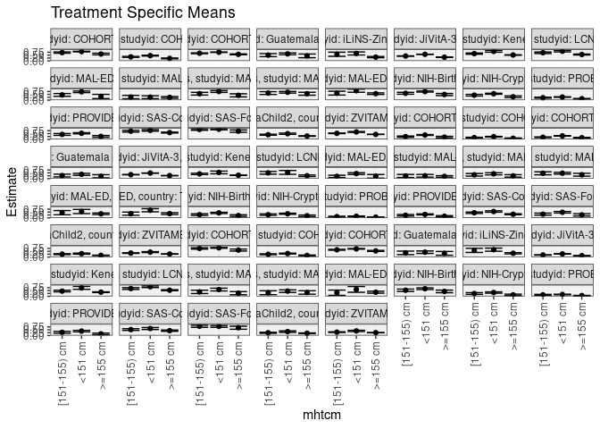

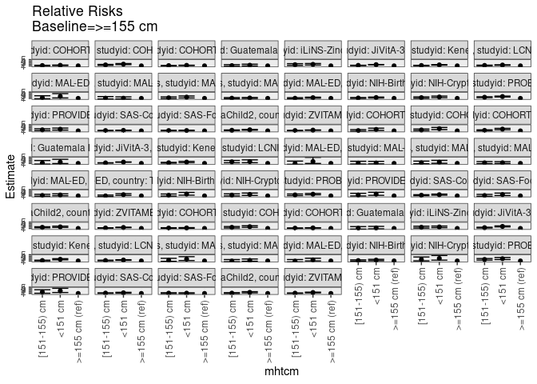

[figure not shown]

[figure not shown]

## Results Table

### Parameter: TSM

| agecat | studyid | country | intervention_level | baseline_level | estimate | ci_lower | ci_upper |
| --- | --- | --- | --- | --- | --- | --- | --- |
| 0-24 months | COHORTS | GUATEMALA | >=155 cm | NA | 0.5987416 | 0.5269844 | 0.6704987 |
| 0-24 months | COHORTS | GUATEMALA | <151 cm | NA | 0.8100173 | 0.7834251 | 0.8366094 |
| 0-24 months | COHORTS | GUATEMALA | [151-155) cm | NA | 0.7231169 | 0.6681910 | 0.7780429 |
| 0-24 months | COHORTS | INDIA | >=155 cm | NA | 0.2190737 | 0.1860432 | 0.2521043 |
| 0-24 months | COHORTS | INDIA | <151 cm | NA | 0.4587440 | 0.4250353 | 0.4924528 |
| 0-24 months | COHORTS | INDIA | [151-155) cm | NA | 0.3510403 | 0.3090453 | 0.3930353 |
| 0-24 months | COHORTS | PHILIPPINES | >=155 cm | NA | 0.5715327 | 0.5336679 | 0.6093974 |
| 0-24 months | COHORTS | PHILIPPINES | <151 cm | NA | 0.7522415 | 0.7310232 | 0.7734598 |
| 0-24 months | COHORTS | PHILIPPINES | [151-155) cm | NA | 0.6621884 | 0.6312177 | 0.6931591 |
| 0-24 months | Guatemala BSC | GUATEMALA | >=155 cm | NA | 0.4376482 | 0.2767712 | 0.5985252 |
| 0-24 months | Guatemala BSC | GUATEMALA | <151 cm | NA | 0.6102970 | 0.5296374 | 0.6909567 |
| 0-24 months | Guatemala BSC | GUATEMALA | [151-155) cm | NA | 0.5036480 | 0.3714562 | 0.6358397 |
| 0-24 months | iLiNS-Zinc | BURKINA FASO | >=155 cm | NA | 0.3302522 | 0.2781027 | 0.3824017 |
| 0-24 months | iLiNS-Zinc | BURKINA FASO | <151 cm | NA | 0.6462755 | 0.5134302 | 0.7791207 |
| 0-24 months | iLiNS-Zinc | BURKINA FASO | [151-155) cm | NA | 0.5780563 | 0.3996522 | 0.7564604 |
| 0-24 months | JiVitA-3 | BANGLADESH | >=155 cm | NA | 0.3222417 | 0.3061171 | 0.3383663 |
| 0-24 months | JiVitA-3 | BANGLADESH | <151 cm | NA | 0.5721350 | 0.5627300 | 0.5815400 |
| 0-24 months | JiVitA-3 | BANGLADESH | [151-155) cm | NA | 0.4226648 | 0.4093334 | 0.4359962 |
| 0-24 months | Keneba | GAMBIA | >=155 cm | NA | 0.5143082 | 0.4924560 | 0.5361604 |
| 0-24 months | Keneba | GAMBIA | <151 cm | NA | 0.8270901 | 0.7523449 | 0.9018353 |
| 0-24 months | Keneba | GAMBIA | [151-155) cm | NA | 0.6327688 | 0.5803969 | 0.6851408 |
| 0-24 months | LCNI-5 | MALAWI | >=155 cm | NA | 0.5548824 | 0.5118294 | 0.5979353 |
| 0-24 months | LCNI-5 | MALAWI | <151 cm | NA | 0.8411363 | 0.7789280 | 0.9033446 |
| 0-24 months | LCNI-5 | MALAWI | [151-155) cm | NA | 0.7069212 | 0.6420316 | 0.7718109 |
| 0-24 months | MAL-ED | BANGLADESH | >=155 cm | NA | 0.3200000 | 0.1367837 | 0.5032163 |
| 0-24 months | MAL-ED | BANGLADESH | <151 cm | NA | 0.7239264 | 0.6551609 | 0.7926919 |
| 0-24 months | MAL-ED | BANGLADESH | [151-155) cm | NA | 0.4545455 | 0.3341803 | 0.5749106 |
| 0-24 months | MAL-ED | BRAZIL | >=155 cm | NA | 0.2357955 | 0.1619880 | 0.3096030 |
| 0-24 months | MAL-ED | BRAZIL | <151 cm | NA | 0.2566798 | 0.1328015 | 0.3805582 |
| 0-24 months | MAL-ED | BRAZIL | [151-155) cm | NA | 0.2665207 | 0.1188780 | 0.4141634 |

[output cut: 153 more lines]

### Parameter: E(Y)

| agecat | studyid | country | intervention_level | baseline_level | estimate | ci_lower | ci_upper |
| --- | --- | --- | --- | --- | --- | --- | --- |
| 0-24 months | COHORTS | GUATEMALA | NA | NA | 0.7662539 | 0.7431681 | 0.7893396 |
| 0-24 months | COHORTS | INDIA | NA | NA | 0.3599161 | 0.3383625 | 0.3814696 |
| 0-24 months | COHORTS | PHILIPPINES | NA | NA | 0.6863963 | 0.6699497 | 0.7028430 |
| 0-24 months | Guatemala BSC | GUATEMALA | NA | NA | 0.5574468 | 0.4938076 | 0.6210860 |
| 0-24 months | iLiNS-Zinc | BURKINA FASO | NA | NA | 0.3566542 | 0.3069876 | 0.4063208 |
| 0-24 months | JiVitA-3 | BANGLADESH | NA | NA | 0.4955360 | 0.4876904 | 0.5033817 |
| 0-24 months | Keneba | GAMBIA | NA | NA | 0.5419753 | 0.5221615 | 0.5617891 |
| 0-24 months | LCNI-5 | MALAWI | NA | NA | 0.6356033 | 0.6029802 | 0.6682264 |
| 0-24 months | MAL-ED | BANGLADESH | NA | NA | 0.6141732 | 0.5541901 | 0.6741564 |
| 0-24 months | MAL-ED | BRAZIL | NA | NA | 0.2612613 | 0.2033404 | 0.3191821 |
| 0-24 months | MAL-ED | INDIA | NA | NA | 0.6157025 | 0.5542897 | 0.6771153 |
| 0-24 months | MAL-ED | PERU | NA | NA | 0.6413793 | 0.5860858 | 0.6966728 |
| 0-24 months | MAL-ED | SOUTH AFRICA | NA | NA | 0.6000000 | 0.5414566 | 0.6585434 |
| 0-24 months | NIH-Birth | BANGLADESH | NA | NA | 0.6645469 | 0.6276196 | 0.7014742 |
| 0-24 months | NIH-Crypto | BANGLADESH | NA | NA | 0.4794702 | 0.4438115 | 0.5151289 |
| 0-24 months | PROBIT | BELARUS | NA | NA | 0.1284404 | 0.1123257 | 0.1445550 |
| 0-24 months | PROVIDE | BANGLADESH | NA | NA | 0.4529148 | 0.4151667 | 0.4906629 |
| 0-24 months | SAS-CompFeed | INDIA | NA | NA | 0.6865672 | 0.6433613 | 0.7297731 |
| 0-24 months | SAS-FoodSuppl | INDIA | NA | NA | 0.8386308 | 0.8029353 | 0.8743263 |
| 0-24 months | TanzaniaChild2 | TANZANIA, UNITED REPUBLIC OF | NA | NA | 0.3454854 | 0.3262920 | 0.3646787 |
| 0-24 months | ZVITAMBO | ZIMBABWE | NA | NA | 0.4585871 | 0.4487474 | 0.4684268 |
| 0-6 months | COHORTS | GUATEMALA | NA | NA | 0.3261682 | 0.2980650 | 0.3542714 |
| 0-6 months | COHORTS | INDIA | NA | NA | 0.1714744 | 0.1543953 | 0.1885534 |
| 0-6 months | COHORTS | PHILIPPINES | NA | NA | 0.2390451 | 0.2239262 | 0.2541640 |
| 0-6 months | Guatemala BSC | GUATEMALA | NA | NA | 0.3196347 | 0.2577308 | 0.3815386 |
| 0-6 months | JiVitA-3 | BANGLADESH | NA | NA | 0.4130547 | 0.4055931 | 0.4205164 |
| 0-6 months | Keneba | GAMBIA | NA | NA | 0.3141798 | 0.2945906 | 0.3337690 |
| 0-6 months | LCNI-5 | MALAWI | NA | NA | 0.3579336 | 0.3007518 | 0.4151153 |
| 0-6 months | MAL-ED | BANGLADESH | NA | NA | 0.3503937 | 0.2916054 | 0.4091820 |
| 0-6 months | MAL-ED | BRAZIL | NA | NA | 0.2117117 | 0.1578516 | 0.2655718 |
| 0-6 months | MAL-ED | INDIA | NA | NA | 0.3471074 | 0.2870050 | 0.4072099 |
| 0-6 months | MAL-ED | PERU | NA | NA | 0.4413793 | 0.3841309 | 0.4986278 |
| 0-6 months | MAL-ED | SOUTH AFRICA | NA | NA | 0.3851852 | 0.3270313 | 0.4433391 |
| 0-6 months | MAL-ED | TANZANIA, UNITED REPUBLIC OF | NA | NA | 0.4218750 | 0.3612599 | 0.4824901 |
| 0-6 months | NIH-Birth | BANGLADESH | NA | NA | 0.3497615 | 0.3124631 | 0.3870600 |
| 0-6 months | NIH-Crypto | BANGLADESH | NA | NA | 0.3033113 | 0.2704998 | 0.3361228 |
| 0-6 months | PROBIT | BELARUS | NA | NA | 0.0656036 | 0.0549747 | 0.0762326 |
| 0-6 months | PROVIDE | BANGLADESH | NA | NA | 0.2481315 | 0.2153770 | 0.2808861 |
| 0-6 months | SAS-CompFeed | INDIA | NA | NA | 0.4266382 | 0.3925570 | 0.4607194 |
| 0-6 months | SAS-FoodSuppl | INDIA | NA | NA | 0.3906634 | 0.3432048 | 0.4381220 |
| 0-6 months | TanzaniaChild2 | TANZANIA, UNITED REPUBLIC OF | NA | NA | 0.1937262 | 0.1777743 | 0.2096780 |
| 0-6 months | ZVITAMBO | ZIMBABWE | NA | NA | 0.2865562 | 0.2776225 | 0.2954900 |
| 6-24 months | COHORTS | GUATEMALA | NA | NA | 0.7612827 | 0.7324712 | 0.7900941 |
| 6-24 months | COHORTS | INDIA | NA | NA | 0.2385621 | 0.2171991 | 0.2599251 |
| 6-24 months | COHORTS | PHILIPPINES | NA | NA | 0.6449788 | 0.6246093 | 0.6653483 |
| 6-24 months | Guatemala BSC | GUATEMALA | NA | NA | 0.3885350 | 0.3120482 | 0.4650219 |
| 6-24 months | iLiNS-Zinc | BURKINA FASO | NA | NA | 0.3566542 | 0.3069876 | 0.4063208 |
| 6-24 months | JiVitA-3 | BANGLADESH | NA | NA | 0.2163480 | 0.2069669 | 0.2257290 |
| 6-24 months | Keneba | GAMBIA | NA | NA | 0.3805837 | 0.3573526 | 0.4038147 |
| 6-24 months | LCNI-5 | MALAWI | NA | NA | 0.5983494 | 0.5626894 | 0.6340094 |
| 6-24 months | MAL-ED | INDIA | NA | NA | 0.4220779 | 0.3438191 | 0.5003367 |
| 6-24 months | MAL-ED | PERU | NA | NA | 0.3918919 | 0.3129763 | 0.4708075 |
| 6-24 months | MAL-ED | SOUTH AFRICA | NA | NA | 0.3741935 | 0.2977649 | 0.4506221 |
| 6-24 months | NIH-Birth | BANGLADESH | NA | NA | 0.5739130 | 0.5216565 | 0.6261696 |
| 6-24 months | NIH-Crypto | BANGLADESH | NA | NA | 0.2628459 | 0.2244546 | 0.3012371 |
| 6-24 months | PROBIT | BELARUS | NA | NA | 0.0672904 | 0.0549305 | 0.0796504 |
| 6-24 months | PROVIDE | BANGLADESH | NA | NA | 0.3004386 | 0.2583143 | 0.3425629 |
| 6-24 months | SAS-CompFeed | INDIA | NA | NA | 0.4939435 | 0.4498186 | 0.5380683 |
| 6-24 months | SAS-FoodSuppl | INDIA | NA | NA | 0.7572016 | 0.7031798 | 0.8112234 |
| 6-24 months | TanzaniaChild2 | TANZANIA, UNITED REPUBLIC OF | NA | NA | 0.2268695 | 0.2061992 | 0.2475397 |
| 6-24 months | ZVITAMBO | ZIMBABWE | NA | NA | 0.2615124 | 0.2508224 | 0.2722024 |

### Parameter: RR

| agecat | studyid | country | intervention_level | baseline_level | estimate | ci_lower | ci_upper |
| --- | --- | --- | --- | --- | --- | --- | --- |
| 0-24 months | COHORTS | GUATEMALA | >=155 cm | >=155 cm | 1.0000000 | 1.0000000 | 1.000000 |
| 0-24 months | COHORTS | GUATEMALA | <151 cm | >=155 cm | 1.3528663 | 1.1950774 | 1.531488 |
| 0-24 months | COHORTS | GUATEMALA | [151-155) cm | >=155 cm | 1.2077280 | 1.0481361 | 1.391620 |
| 0-24 months | COHORTS | INDIA | >=155 cm | >=155 cm | 1.0000000 | 1.0000000 | 1.000000 |
| 0-24 months | COHORTS | INDIA | <151 cm | >=155 cm | 2.0940166 | 1.7729178 | 2.473271 |
| 0-24 months | COHORTS | INDIA | [151-155) cm | >=155 cm | 1.6023843 | 1.3227263 | 1.941169 |
| 0-24 months | COHORTS | PHILIPPINES | >=155 cm | >=155 cm | 1.0000000 | 1.0000000 | 1.000000 |
| 0-24 months | COHORTS | PHILIPPINES | <151 cm | >=155 cm | 1.3161829 | 1.2252829 | 1.413827 |
| 0-24 months | COHORTS | PHILIPPINES | [151-155) cm | >=155 cm | 1.1586186 | 1.0690453 | 1.255697 |
| 0-24 months | Guatemala BSC | GUATEMALA | >=155 cm | >=155 cm | 1.0000000 | 1.0000000 | 1.000000 |
| 0-24 months | Guatemala BSC | GUATEMALA | <151 cm | >=155 cm | 1.3944923 | 0.9445559 | 2.058755 |
| 0-24 months | Guatemala BSC | GUATEMALA | [151-155) cm | >=155 cm | 1.1508056 | 0.7342303 | 1.803731 |
| 0-24 months | iLiNS-Zinc | BURKINA FASO | >=155 cm | >=155 cm | 1.0000000 | 1.0000000 | 1.000000 |
| 0-24 months | iLiNS-Zinc | BURKINA FASO | <151 cm | >=155 cm | 1.9569150 | 1.5224243 | 2.515407 |
| 0-24 months | iLiNS-Zinc | BURKINA FASO | [151-155) cm | >=155 cm | 1.7503482 | 1.2826380 | 2.388607 |
| 0-24 months | JiVitA-3 | BANGLADESH | >=155 cm | >=155 cm | 1.0000000 | 1.0000000 | 1.000000 |
| 0-24 months | JiVitA-3 | BANGLADESH | <151 cm | >=155 cm | 1.7754840 | 1.6876311 | 1.867910 |
| 0-24 months | JiVitA-3 | BANGLADESH | [151-155) cm | >=155 cm | 1.3116391 | 1.2377089 | 1.389985 |
| 0-24 months | Keneba | GAMBIA | >=155 cm | >=155 cm | 1.0000000 | 1.0000000 | 1.000000 |
| 0-24 months | Keneba | GAMBIA | <151 cm | >=155 cm | 1.6081603 | 1.4552200 | 1.777174 |
| 0-24 months | Keneba | GAMBIA | [151-155) cm | >=155 cm | 1.2303300 | 1.1212143 | 1.350065 |
| 0-24 months | LCNI-5 | MALAWI | >=155 cm | >=155 cm | 1.0000000 | 1.0000000 | 1.000000 |
| 0-24 months | LCNI-5 | MALAWI | <151 cm | >=155 cm | 1.5158822 | 1.3615834 | 1.687666 |
| 0-24 months | LCNI-5 | MALAWI | [151-155) cm | >=155 cm | 1.2740019 | 1.1296917 | 1.436747 |
| 0-24 months | MAL-ED | BANGLADESH | >=155 cm | >=155 cm | 1.0000000 | 1.0000000 | 1.000000 |
| 0-24 months | MAL-ED | BANGLADESH | <151 cm | >=155 cm | 2.2622699 | 1.2661636 | 4.042025 |
| 0-24 months | MAL-ED | BANGLADESH | [151-155) cm | >=155 cm | 1.4204545 | 0.7559014 | 2.669252 |
| 0-24 months | MAL-ED | BRAZIL | >=155 cm | >=155 cm | 1.0000000 | 1.0000000 | 1.000000 |
| 0-24 months | MAL-ED | BRAZIL | <151 cm | >=155 cm | 1.0885697 | 0.6123843 | 1.935033 |
| 0-24 months | MAL-ED | BRAZIL | [151-155) cm | >=155 cm | 1.1303044 | 0.5958131 | 2.144277 |

[output cut: 153 more lines]

### Parameter: PAR

| agecat | studyid | country | intervention_level | baseline_level | estimate | ci_lower | ci_upper |
| --- | --- | --- | --- | --- | --- | --- | --- |
| 0-24 months | COHORTS | GUATEMALA | >=155 cm | NA | 0.1675123 | 0.1016214 | 0.2334032 |
| 0-24 months | COHORTS | INDIA | >=155 cm | NA | 0.1408423 | 0.1110738 | 0.1706108 |
| 0-24 months | COHORTS | PHILIPPINES | >=155 cm | NA | 0.1148637 | 0.0818872 | 0.1478401 |
| 0-24 months | Guatemala BSC | GUATEMALA | >=155 cm | NA | 0.1197986 | -0.0282876 | 0.2678849 |
| 0-24 months | iLiNS-Zinc | BURKINA FASO | >=155 cm | NA | 0.0264020 | 0.0161813 | 0.0366227 |
| 0-24 months | JiVitA-3 | BANGLADESH | >=155 cm | NA | 0.1732944 | 0.1585168 | 0.1880719 |
| 0-24 months | Keneba | GAMBIA | >=155 cm | NA | 0.0276671 | 0.0188085 | 0.0365256 |
| 0-24 months | LCNI-5 | MALAWI | >=155 cm | NA | 0.0807210 | 0.0552510 | 0.1061910 |
| 0-24 months | MAL-ED | BANGLADESH | >=155 cm | NA | 0.2941732 | 0.1193640 | 0.4689825 |
| 0-24 months | MAL-ED | BRAZIL | >=155 cm | NA | 0.0254658 | -0.0243426 | 0.0752742 |
| 0-24 months | MAL-ED | INDIA | >=155 cm | NA | 0.1981254 | 0.0806864 | 0.3155644 |
| 0-24 months | MAL-ED | PERU | >=155 cm | NA | 0.0863560 | -0.0266046 | 0.1993167 |
| 0-24 months | MAL-ED | SOUTH AFRICA | >=155 cm | NA | 0.0362745 | 0.0038482 | 0.0687008 |
| 0-24 months | NIH-Birth | BANGLADESH | >=155 cm | NA | 0.1773629 | 0.0970213 | 0.2577046 |
| 0-24 months | NIH-Crypto | BANGLADESH | >=155 cm | NA | 0.1849818 | 0.1157189 | 0.2542447 |
| 0-24 months | PROBIT | BELARUS | >=155 cm | NA | 0.0041262 | 0.0026985 | 0.0055539 |
| 0-24 months | PROVIDE | BANGLADESH | >=155 cm | NA | 0.1957054 | 0.1269922 | 0.2644186 |
| 0-24 months | SAS-CompFeed | INDIA | >=155 cm | NA | 0.0963602 | 0.0753938 | 0.1173266 |
| 0-24 months | SAS-FoodSuppl | INDIA | >=155 cm | NA | 0.1233487 | 0.0349517 | 0.2117456 |
| 0-24 months | TanzaniaChild2 | TANZANIA, UNITED REPUBLIC OF | >=155 cm | NA | 0.0554356 | 0.0402639 | 0.0706072 |
| 0-24 months | ZVITAMBO | ZIMBABWE | >=155 cm | NA | 0.0250237 | 0.0199656 | 0.0300818 |
| 0-6 months | COHORTS | GUATEMALA | >=155 cm | NA | 0.1284663 | 0.0642780 | 0.1926546 |
| 0-6 months | COHORTS | INDIA | >=155 cm | NA | 0.0745330 | 0.0514711 | 0.0975948 |
| 0-6 months | COHORTS | PHILIPPINES | >=155 cm | NA | 0.0969478 | 0.0710018 | 0.1228938 |
| 0-6 months | Guatemala BSC | GUATEMALA | >=155 cm | NA | 0.1137524 | -0.0151939 | 0.2426986 |
| 0-6 months | JiVitA-3 | BANGLADESH | >=155 cm | NA | 0.1523890 | 0.1379542 | 0.1668238 |
| 0-6 months | Keneba | GAMBIA | >=155 cm | NA | 0.0228072 | 0.0132887 | 0.0323257 |
| 0-6 months | LCNI-5 | MALAWI | >=155 cm | NA | 0.1082647 | 0.0587899 | 0.1577396 |
| 0-6 months | MAL-ED | BANGLADESH | >=155 cm | NA | 0.1503937 | -0.0021835 | 0.3029709 |
| 0-6 months | MAL-ED | BRAZIL | >=155 cm | NA | 0.0194040 | -0.0265493 | 0.0653573 |
| 0-6 months | MAL-ED | INDIA | >=155 cm | NA | 0.1111440 | 0.0123074 | 0.2099805 |
| 0-6 months | MAL-ED | PERU | >=155 cm | NA | 0.1057498 | -0.0059449 | 0.2174445 |
| 0-6 months | MAL-ED | SOUTH AFRICA | >=155 cm | NA | 0.0376313 | 0.0026299 | 0.0726327 |
| 0-6 months | MAL-ED | TANZANIA, UNITED REPUBLIC OF | >=155 cm | NA | 0.0567528 | 0.0062997 | 0.1072060 |
| 0-6 months | NIH-Birth | BANGLADESH | >=155 cm | NA | 0.1544176 | 0.0853904 | 0.2234448 |
| 0-6 months | NIH-Crypto | BANGLADESH | >=155 cm | NA | 0.1221571 | 0.0612361 | 0.1830781 |
| 0-6 months | PROBIT | BELARUS | >=155 cm | NA | 0.0018762 | 0.0007671 | 0.0029853 |
| 0-6 months | PROVIDE | BANGLADESH | >=155 cm | NA | 0.1091271 | 0.0549895 | 0.1632646 |
| 0-6 months | SAS-CompFeed | INDIA | >=155 cm | NA | 0.1170406 | 0.0783822 | 0.1556991 |
| 0-6 months | SAS-FoodSuppl | INDIA | >=155 cm | NA | 0.1330062 | 0.0427351 | 0.2232773 |
| 0-6 months | TanzaniaChild2 | TANZANIA, UNITED REPUBLIC OF | >=155 cm | NA | 0.0449058 | 0.0318957 | 0.0579160 |
| 0-6 months | ZVITAMBO | ZIMBABWE | >=155 cm | NA | 0.0213386 | 0.0165095 | 0.0261677 |
| 6-24 months | COHORTS | GUATEMALA | >=155 cm | NA | 0.1550245 | 0.0780625 | 0.2319866 |
| 6-24 months | COHORTS | INDIA | >=155 cm | NA | 0.0956008 | 0.0678324 | 0.1233692 |
| 6-24 months | COHORTS | PHILIPPINES | >=155 cm | NA | 0.1105660 | 0.0737980 | 0.1473340 |
| 6-24 months | Guatemala BSC | GUATEMALA | >=155 cm | NA | 0.0672553 | -0.0821145 | 0.2166251 |
| 6-24 months | iLiNS-Zinc | BURKINA FASO | >=155 cm | NA | 0.0261866 | 0.0157855 | 0.0365878 |
| 6-24 months | JiVitA-3 | BANGLADESH | >=155 cm | NA | 0.0960998 | 0.0808632 | 0.1113364 |
| 6-24 months | Keneba | GAMBIA | >=155 cm | NA | 0.0227929 | 0.0125181 | 0.0330677 |
| 6-24 months | LCNI-5 | MALAWI | >=155 cm | NA | 0.0713780 | 0.0449821 | 0.0977739 |
| 6-24 months | MAL-ED | INDIA | >=155 cm | NA | 0.1527493 | 0.0301146 | 0.2753840 |
| 6-24 months | MAL-ED | PERU | >=155 cm | NA | 0.0585586 | -0.0704796 | 0.1875967 |
| 6-24 months | MAL-ED | SOUTH AFRICA | >=155 cm | NA | 0.0193548 | -0.0201224 | 0.0588320 |
| 6-24 months | NIH-Birth | BANGLADESH | >=155 cm | NA | 0.1477831 | 0.0505387 | 0.2450274 |
| 6-24 months | NIH-Crypto | BANGLADESH | >=155 cm | NA | 0.1376018 | 0.0757534 | 0.1994503 |
| 6-24 months | PROBIT | BELARUS | >=155 cm | NA | 0.0025845 | 0.0014553 | 0.0037136 |
| 6-24 months | PROVIDE | BANGLADESH | >=155 cm | NA | 0.1551082 | 0.0905436 | 0.2196728 |
| 6-24 months | SAS-CompFeed | INDIA | >=155 cm | NA | 0.0701483 | 0.0293705 | 0.1109261 |
| 6-24 months | SAS-FoodSuppl | INDIA | >=155 cm | NA | 0.0799099 | -0.0309539 | 0.1907736 |
| 6-24 months | TanzaniaChild2 | TANZANIA, UNITED REPUBLIC OF | >=155 cm | NA | 0.0274895 | 0.0122332 | 0.0427458 |
| 6-24 months | ZVITAMBO | ZIMBABWE | >=155 cm | NA | 0.0131398 | 0.0078381 | 0.0184416 |

### Parameter: PAF

| agecat | studyid | country | intervention_level | baseline_level | estimate | ci_lower | ci_upper |
| --- | --- | --- | --- | --- | --- | --- | --- |
| 0-24 months | COHORTS | GUATEMALA | >=155 cm | NA | 0.2186120 | 0.1267701 | 0.3007945 |
| 0-24 months | COHORTS | INDIA | >=155 cm | NA | 0.3913199 | 0.3043697 | 0.4674018 |
| 0-24 months | COHORTS | PHILIPPINES | >=155 cm | NA | 0.1673431 | 0.1174151 | 0.2144466 |
| 0-24 months | Guatemala BSC | GUATEMALA | >=155 cm | NA | 0.2149059 | -0.1026259 | 0.4409957 |
| 0-24 months | iLiNS-Zinc | BURKINA FASO | >=155 cm | NA | 0.0740270 | 0.0416325 | 0.1053265 |
| 0-24 months | JiVitA-3 | BANGLADESH | >=155 cm | NA | 0.3497109 | 0.3191553 | 0.3788952 |
| 0-24 months | Keneba | GAMBIA | >=155 cm | NA | 0.0510486 | 0.0344194 | 0.0673914 |
| 0-24 months | LCNI-5 | MALAWI | >=155 cm | NA | 0.1269989 | 0.0848747 | 0.1671841 |
| 0-24 months | MAL-ED | BANGLADESH | >=155 cm | NA | 0.4789744 | 0.0959206 | 0.6997302 |
| 0-24 months | MAL-ED | BRAZIL | >=155 cm | NA | 0.0974725 | -0.1145220 | 0.2691432 |
| 0-24 months | MAL-ED | INDIA | >=155 cm | NA | 0.3217875 | 0.0971669 | 0.4905236 |
| 0-24 months | MAL-ED | PERU | >=155 cm | NA | 0.1346411 | -0.0616263 | 0.2946238 |
| 0-24 months | MAL-ED | SOUTH AFRICA | >=155 cm | NA | 0.0604575 | 0.0042120 | 0.1135261 |
| 0-24 months | NIH-Birth | BANGLADESH | >=155 cm | NA | 0.2668930 | 0.1335206 | 0.3797362 |
| 0-24 months | NIH-Crypto | BANGLADESH | >=155 cm | NA | 0.3858045 | 0.2224013 | 0.5148705 |
| 0-24 months | PROBIT | BELARUS | >=155 cm | NA | 0.0321255 | 0.0215751 | 0.0425621 |
| 0-24 months | PROVIDE | BANGLADESH | >=155 cm | NA | 0.4321020 | 0.2586345 | 0.5649810 |
| 0-24 months | SAS-CompFeed | INDIA | >=155 cm | NA | 0.1403507 | 0.1133110 | 0.1665658 |
| 0-24 months | SAS-FoodSuppl | INDIA | >=155 cm | NA | 0.1470834 | 0.0332028 | 0.2475498 |
| 0-24 months | TanzaniaChild2 | TANZANIA, UNITED REPUBLIC OF | >=155 cm | NA | 0.1604570 | 0.1154673 | 0.2031585 |
| 0-24 months | ZVITAMBO | ZIMBABWE | >=155 cm | NA | 0.0545670 | 0.0434357 | 0.0655687 |
| 0-6 months | COHORTS | GUATEMALA | >=155 cm | NA | 0.3938651 | 0.1629593 | 0.5610733 |
| 0-6 months | COHORTS | INDIA | >=155 cm | NA | 0.4346595 | 0.2904441 | 0.5495635 |
| 0-6 months | COHORTS | PHILIPPINES | >=155 cm | NA | 0.4055627 | 0.2889922 | 0.5030214 |
| 0-6 months | Guatemala BSC | GUATEMALA | >=155 cm | NA | 0.3558824 | -0.2005949 | 0.6544317 |
| 0-6 months | JiVitA-3 | BANGLADESH | >=155 cm | NA | 0.3689317 | 0.3331256 | 0.4028153 |
| 0-6 months | Keneba | GAMBIA | >=155 cm | NA | 0.0725929 | 0.0418485 | 0.1023508 |
| 0-6 months | LCNI-5 | MALAWI | >=155 cm | NA | 0.3024715 | 0.1513136 | 0.4267070 |
| 0-6 months | MAL-ED | BANGLADESH | >=155 cm | NA | 0.4292135 | -0.2191174 | 0.7327597 |
| 0-6 months | MAL-ED | BRAZIL | >=155 cm | NA | 0.0916530 | -0.1527165 | 0.2842176 |
| 0-6 months | MAL-ED | INDIA | >=155 cm | NA | 0.3202005 | -0.0286579 | 0.5507473 |
| 0-6 months | MAL-ED | PERU | >=155 cm | NA | 0.2395895 | -0.0614072 | 0.4552287 |
| 0-6 months | MAL-ED | SOUTH AFRICA | >=155 cm | NA | 0.0976966 | 0.0020021 | 0.1842153 |
| 0-6 months | MAL-ED | TANZANIA, UNITED REPUBLIC OF | >=155 cm | NA | 0.1345252 | 0.0055744 | 0.2467545 |
| 0-6 months | NIH-Birth | BANGLADESH | >=155 cm | NA | 0.4414939 | 0.2076321 | 0.6063330 |
| 0-6 months | NIH-Crypto | BANGLADESH | >=155 cm | NA | 0.4027451 | 0.1668764 | 0.5718361 |
| 0-6 months | PROBIT | BELARUS | >=155 cm | NA | 0.0285991 | 0.0120301 | 0.0448902 |
| 0-6 months | PROVIDE | BANGLADESH | >=155 cm | NA | 0.4397952 | 0.1806922 | 0.6169578 |
| 0-6 months | SAS-CompFeed | INDIA | >=155 cm | NA | 0.2743323 | 0.1834068 | 0.3551334 |
| 0-6 months | SAS-FoodSuppl | INDIA | >=155 cm | NA | 0.3404624 | 0.0650759 | 0.5347325 |
| 0-6 months | TanzaniaChild2 | TANZANIA, UNITED REPUBLIC OF | >=155 cm | NA | 0.2318005 | 0.1635094 | 0.2945164 |
| 0-6 months | ZVITAMBO | ZIMBABWE | >=155 cm | NA | 0.0744658 | 0.0575035 | 0.0911229 |
| 6-24 months | COHORTS | GUATEMALA | >=155 cm | NA | 0.2036360 | 0.0946397 | 0.2995102 |
| 6-24 months | COHORTS | INDIA | >=155 cm | NA | 0.4007377 | 0.2772913 | 0.5030981 |
| 6-24 months | COHORTS | PHILIPPINES | >=155 cm | NA | 0.1714258 | 0.1118716 | 0.2269865 |
| 6-24 months | Guatemala BSC | GUATEMALA | >=155 cm | NA | 0.1730997 | -0.3151892 | 0.4801021 |
| 6-24 months | iLiNS-Zinc | BURKINA FASO | >=155 cm | NA | 0.0734231 | 0.0404433 | 0.1052694 |
| 6-24 months | JiVitA-3 | BANGLADESH | >=155 cm | NA | 0.4441908 | 0.3719471 | 0.5081245 |
| 6-24 months | Keneba | GAMBIA | >=155 cm | NA | 0.0598893 | 0.0324524 | 0.0865481 |
| 6-24 months | LCNI-5 | MALAWI | >=155 cm | NA | 0.1192916 | 0.0730717 | 0.1632067 |
| 6-24 months | MAL-ED | INDIA | >=155 cm | NA | 0.3618984 | -0.0018890 | 0.5935940 |
| 6-24 months | MAL-ED | PERU | >=155 cm | NA | 0.1494253 | -0.2528576 | 0.4225383 |
| 6-24 months | MAL-ED | SOUTH AFRICA | >=155 cm | NA | 0.0517241 | -0.0599469 | 0.1516301 |
| 6-24 months | NIH-Birth | BANGLADESH | >=155 cm | NA | 0.2575008 | 0.0649956 | 0.4103717 |
| 6-24 months | NIH-Crypto | BANGLADESH | >=155 cm | NA | 0.5235078 | 0.2292731 | 0.7054147 |
| 6-24 months | PROBIT | BELARUS | >=155 cm | NA | 0.0384074 | 0.0205714 | 0.0559187 |
| 6-24 months | PROVIDE | BANGLADESH | >=155 cm | NA | 0.5162726 | 0.2562344 | 0.6853952 |
| 6-24 months | SAS-CompFeed | INDIA | >=155 cm | NA | 0.1420169 | 0.0561580 | 0.2200655 |
| 6-24 months | SAS-FoodSuppl | INDIA | >=155 cm | NA | 0.1055331 | -0.0550053 | 0.2416427 |
| 6-24 months | TanzaniaChild2 | TANZANIA, UNITED REPUBLIC OF | >=155 cm | NA | 0.1211690 | 0.0517445 | 0.1855107 |
| 6-24 months | ZVITAMBO | ZIMBABWE | >=155 cm | NA | 0.0502456 | 0.0297955 | 0.0702647 |